# Everyone Has Been Wrong for 280 Years?

# Dismiss Utility Theory for Multiplicative Effects?!?!

Ole Peters and Murray Gell-Mann [1,2] have gone to great lengths to try to persuade us that wealth dynamics follow a multiplicative process and that expected utility does not tell us what happens over time.

[figure not shown]

The math works out, there is no arguing the manipulation of the logarithms. So that’s it? Everyone should just adopt the objective of maximizing the exponential growth rate of wealth, regardless of all other considerations and dispense with utility theory?

[figure not shown]

Not so fast…

# Components of the Multiplicative Effects

What is true of a series of returns and its mean log returns? The larger the components, the larger the mean log returns.

While it is widely understood that volatility lowers a compounded growth rate $(\mu -\frac{\sigma^2}{2})$, it’s actually the downside volatility that is solely responsible. Are you going to argue that upside volatility lowers your growth rate?!?!

Since the downside volatility is responsible, then minimizing the lower partial moment (LPM) of the distribution will increase the mean log returns.

Furthermore, maximizing the upper partial moment (UPM) of the distribution will increase the mean log returns.

Given log returns are normalized to 1, the target of the LPM and UPM will be 1 and we shall demonstrate these effects.

# Start with a Normal distribution of returns

100 observations…

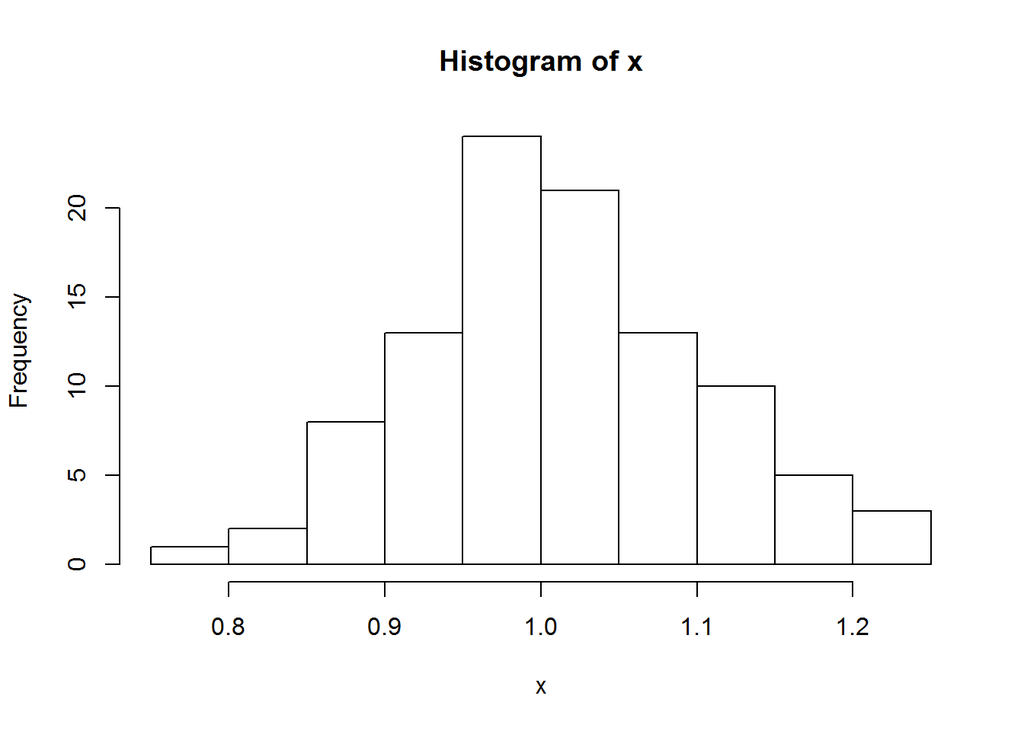

```r
set.seed(123)
x=rlnorm(100, meanlog = 0, sdlog = .1)
hist(x)
```

```r
require(NNS)
options(digits = 8)
```

Let’s compute the mean, geometric mean and the arithmetic mean with partial moments: $1+[UPM(1,1,x)-LPM(1,1,x)]$:

```r
options(digits = 8)
# Arithmetic mean
mean(x)
```

```
## [1] 1.0132593
```

```r
# Geometric mean
exp(mean(log(x)))
```

```
## [1] 1.0090816
```

```r
# Arithmetic mean with paritial moments = Target + [UPM - LPM]
1+(UPM(1,1,x)-LPM(1,1,x))
```

```
## [1] 1.0132593
```

Now that we have our equivalences, we can isolate specific effects.

# Scenario 1: A Larger LPM

We will lower a single below target observation by 0.0001. This will:

- Lower the arithmetic mean
- Lower the geometric mean
- Increase the LPM

The 50th observation is:

```r
x[50]
```

```
## [1] 0.99169775
```

we will lower it by 0.0001 and replace it, calling our new variable `x.50`.

```r
x.50=x
x.50[50]=x[50]-.0001
```

Now let’s see the stats:

```r
# Arithmetic mean
print(c("mean x:"=mean(x),"mean x.50:"=mean(x.50)))
```

```
##    mean x: mean x.50:
##  1.0132593  1.0132583
```

```r
# Geometric mean
print(c("geometric mean x:"=exp(mean(log(x))),"geometric mean x.50:"=exp(mean(log(x.50)))))
```

```
##    geometric mean x: geometric mean x.50:
##            1.0090816            1.0090806
```

```r
# Compare UPMs and LPMs
x_results=cbind(LPM(1,1,x),UPM(1,1,x))

x.50_results=cbind(LPM(1,1,x.50),UPM(1,1,x.50))

x.50_results=rbind(x_results,x.50_results)

colnames(x.50_results)=c("LPM","UPM")
rownames(x.50_results)=c("x","x.50")

x.50_results
```

```
##              LPM         UPM
## x    0.030369897 0.043629187
## x.50 0.030370897 0.043629187
```

So what does this tell us? The area of the lower part of the distribution increased (larger LPM for `x.50`), and the arithmetic, geometric means were lowered.

**We can raise our mean log returns by lowering our LPM.**

# Scenario 2: A larger UPM

We will raise a single above target observation by 0.0001. This will:

- Raise the arithmetic mean
- Raise the geometric mean
- Increase the UPM

The 51st observation is:

```r
x[51]
```

```
## [1] 1.0256554
```

we will raise it by 0.0001 and replace it, calling our new variable `x.51`.

```r
x.51=x
x.51[51]=x[51]+.0001
```

Now let’s see the stats:

```r
# Arithmetic mean
print(c("mean x:"=mean(x),"mean x.51:"=mean(x.51)))
```

```
##    mean x: mean x.51:
##  1.0132593  1.0132603
```

```r
# Geometric mean
print(c("geometric mean x:"=exp(mean(log(x))),"geometric mean x.51:"=exp(mean(log(x.51)))))
```

```
##    geometric mean x: geometric mean x.51:
##            1.0090816            1.0090826
```

```r
# Compare UPMs and LPMs
x.51_results=cbind(LPM(1,1,x.51),UPM(1,1,x.51))

x.51_results=rbind(x_results,x.51_results)
colnames(x.51_results)=c("LPM","UPM")
rownames(x.51_results)=c("x","x.51")

x.51_results
```

```
##              LPM         UPM
## x    0.030369897 0.043629187
## x.51 0.030369897 0.043630187
```

So what does this tell us? The area of the upper part of the distribution increased (larger UPM for `x.51`), and the arithmetic, geometric means were raised.

**We have 2 ways to raise our mean log returns, lower the LPM or raise the UPM.**

# Partial Moments and Utility Functions

Now that we have seen the effects of partial moments with the corresponding multiplicative effects of the distribution of log returns, we can compare multiplicative effects between distributions of log returns using partial moments.

Peters [2] states,  
*“The ‘expected change of logarithmic utility’ is nothing but the time-average growth rate of wealth, under multiplicative dynamics.”*

While log returns (not log price) are an ergodic variable, this desired property for multiplicative processes does not negate the common sense utility implications from gains and losses. Peters and Gell-Mann do not hide the equivalence to log utility.

Partial moments can fit any known utility function in the literature [3]. To replicate a concave everywhere log utility function, we set the degree of the LPM to ($e$) and set the degree of the UPM to $(1/e)$. Of course, this would suggest the investor is risk-averse not only for losses, but gains as well!

Does this seem like a recipe all investors should adopt? No. This is completely sound for the domain of losses, as log utility and every other concave utility function for losses has some admirable self-preserving properties. However, it is deficient in its treatment of gains. No investor should be **(or is)** risk-averse or less than linear with gains…

Samuelson [4] said it best,

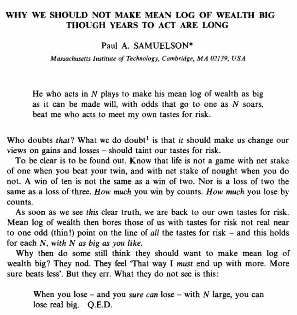

Thorp et al. [5] offer this warning as well,

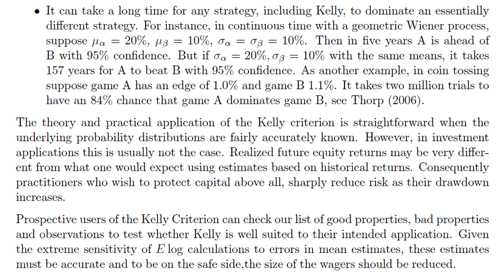

Peters [2] concludes,  
*“Once this concept has sunk in — that gambles are evaluated according to the growth rates they generate for those who engage in them — the type of confusion that surrounds EUT becomes almost impossible.”*

Our contention:  
Perhaps people over the last 280 years evaluated gambles by realizing the simple truth: *that components of the evaluated gambles are directly responsible for these vaunted growth rates, and subjectively weighting the components via utility theory accomplishes the same axiomatic goal where more wealth is preferred with the least amount of losses along the way.*

# References

[1] http://aip.scitation.org/doi/10.1063/1.4940236

[2] https://ergodicityeconomics.com/2018/02/16/the-trouble-with-bernoulli-1738/

[3] https://www.linkedin.com/pulse/behavioral-finance-partial-moments-fred-viole/

[4] https://www.scribd.com/document/332785188/Samuelson-Kelly

[5] https://www.stat.berkeley.edu/~aldous/157/Papers/Good_Bad_Kelly.pdf